# Ejemplo:Simulación de Precios de Acciones en la Bolsa

Magdiel Ablan

23/03/2015

Ejercicio propuesto en: Jones Owen, Robert Maillardet, and Andrew Robinson. 2009. *Introduction to Scientific Programming and Simulation Using R*. Chapman and Hall/CRC

## Simulación de Precios de Acciones en la Bolsa

Un modelo para los precios de índices bursátiles usado comúnmente es el modelo de movimiento geométrico browiano. Sea S(i) el precio de una acción al cierre del día i. El modelo browniano es:

$$S(i+1) = S(i)e^{\mu-\frac{1}{2} \sigma^2+\sqrt{\sigma^2}Z(i+1)}$$

donde donde Z(i) son VA normales estándar. A $\mu$ se le llama el retorno medio y a $\sigma^2$ la volatilidad. Ambos parámetros deben ser estimados del comportamiento previo del índice bursátil.

1. Escriba un programa que tome como entrada los valores de $\mu$, $\sigma^2$, S(0) y t, simule S(1), S(2),….S(t) y los grafique. Incluya en su reporte gráficos ejemplo de por lo menos dos valores de $\sigma^2$ y $\mu$ y describa cualitativamente que pasa.

La siguiente función calcula la evolución de la bolsa con los parámetros dados por T unidades de tiempo:

```r
bolsa<-function(T,mu,sigma2,S0) {
  S<-numeric(T)
  S[1]<-S0
  for (i in 1:(T-1)) {
    S[i+1] = S[i]*exp(mu-0.5*sigma2 + sqrt(sigma2)*rnorm(1))
  }
 return(S)
}
```

Y ahora realizamos varias corridas comparando el efecto de los dos parámetros:

```r
set.seed(321)
T<-100
t<-seq(1,T)
S1<-numeric(T); S2<-numeric(T); S3<-numeric(T)

S1<-bolsa(T,0.05,0.01,20)
S2<-bolsa(T,0.05,0.1,20)
S3<-bolsa(T,0.02,0.01,20)
```

Y hacemos los gráficos correspondientes para visualizar mejor el efecto de los parámetros. Este gráfico compara el efecto de diferentes valores de volatibilidad:

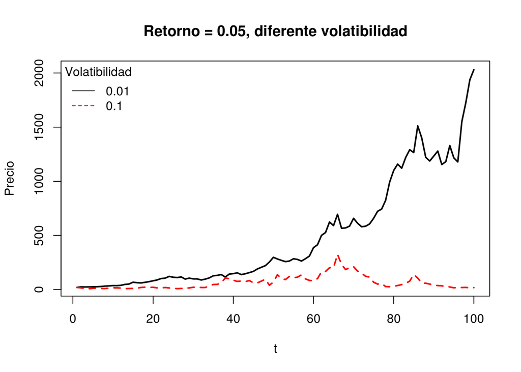

```r
plot(t,S1,type="l",xlab="t",lwd=2,ylab="Precio",main="Retorno = 0.05, diferente volatibilidad")
lines(t,S2,lwd=2,lty=2,col=2)
texto<-c("0.01","0.1")
legend("topleft",texto,title="Volatibilidad",lty=c(1,2),col=c(1,2),lwd=c(1,1),bty="n")
```

Y este el efecto de diferentes valores de retorno:

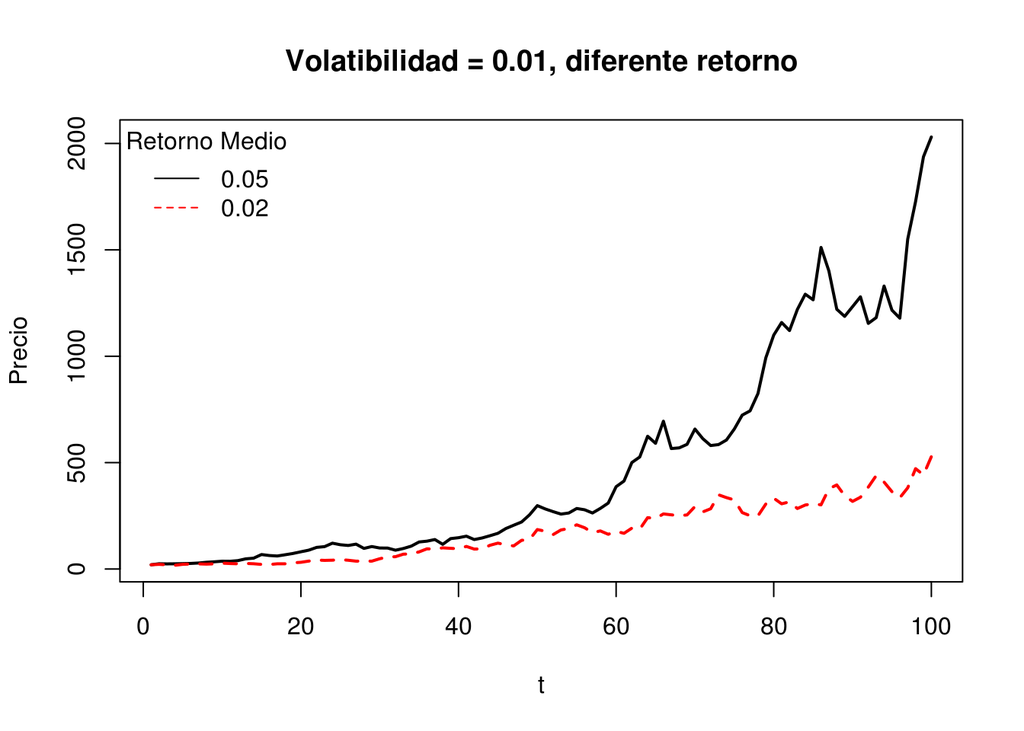

```r
plot(t,S1,type="l",xlab="t",lwd=2,ylab="Precio",main="Volatibilidad = 0.01, diferente retorno")
lines(t,S3,lty=2,lwd=2,col=2)
texto<-c("0.05","0.02")
legend("topleft",texto,lty=c(1,2),col=c(1,2),title="Retorno Medio",lwd=c(1,1),bty="n")
```

| $\mu$ | 0.05 | 0.01 | 0.01 |
| --- | --- | --- | --- |
| $\sigma^2$ | 0.0025 | 0.0025 | 0.01 |
| E[S(100)] |  |  |  |
| 95% IC E(S(100)) |  |  |  |
| P(S(100) > S(0)) |  |  |  |
| 95% IC P(S(100) > S(0)) |  |  |  |

En lo siguiente S100a representa los cálculos para la primera columna, S100b para la segunda y S100c para la tercera:

```r
m<-1000
T<-100
S0= 100

s100a<-numeric(m)
s100a<-replicate(m,expr={S1<-bolsa(T,0.05,0.0025,S0);S1[100]})
s100a.estas<-t.test(s100a)

s100b<-numeric(m)
s100b<-replicate(m,expr={S2<-bolsa(T,0.01,0.0025,S0);S2[100]})
s100b.estas<-t.test(s100b)

s100c<-numeric(m)
s100c<-replicate(m,expr={S3<-bolsa(T,0.01,0.01,S0);S3[100]})
s100c.estas<-t.test(s100c)
```

Y los cálculos asociados a las dos últimas filas de la tabla son como sigue. Note que para el primer caso siempre S(100) es mayor a S(0) y por lo tanto la instrucción para el cálculo de confianza genera un error, por eso se encuentran comentadas

```r
#s0a<-numeric(m)
#s0a<-as.numeric(s100a > S0)
#s0a.estas<-t.test(s0a)

s0b<-numeric(m)
s0b<-as.numeric(s100b > S0)
s0b.estas<-t.test(s0b)

s0c<-numeric(m)
s0c<-as.numeric(s100c > S0)
s0c.estas<-t.test(s0c)
```

Así, la tabla queda como:

[output not shown]